# Predicting Sales on Black Friday

Chip Irek

## 1 - Problem statement

Predict sales.

Build a model to predict the purchase amount of a customer using attributes which will help create personalized offer for customers against different products.

## 2 - Data dictionary

It looks like we have 12 different columns, each representing a corresponding variable below.

- User_ID: Unique identifier of shopper.
- Product_ID: Unique identifier of product. (No key given)
- Gender: Sex of shopper.
- Age: Age of shopper split into bins.
- Occupation: Occupation of shopper. (No key given)
- City_Category: Residence location of shopper. (No key given)
- Stay_In_Current_City_Years: Number of years stay in current city.
- Marital_Status: Marital status of shopper.
- Product_Category_1: Product category of purchase.
- Product_Category_2: Product may belong to other category.
- Product_Category_3: Product may belong to other category.
- Purchase: Purchase amount in dollars.

*Hackathon winner was ~2500*

## 3 - Install the libraries

```r
options(warn=-1)
library(elasticnet)
library(caret)
library(plyr)
library(dplyr)
library(skimr)
library(RANN)
library(e1071)
library(PerformanceAnalytics)
library(outliers)
library(xgboost)
library(ranger)
library(sqldf)
```

## 4 - Explore the data

```r
#dataset.training <- read.csv('train.csv')
dataset.training <- read.csv('train_small.csv')
str(dataset.training)
```

```
## 'data.frame':    995 obs. of  12 variables:
##  $ User_ID                   : int  1000001 1000001 1000001 1000001 1000002 1000003 1000004 1000004 1000004 1000005 ...
##  $ Product_ID                : Factor w/ 706 levels "P00000142","P00000642",..: 142 493 171 163 559 392 372 661 699 536 ...
##  $ Gender                    : Factor w/ 2 levels "F","M": 1 1 1 1 2 2 2 2 2 2 ...
##  $ Age                       : Factor w/ 7 levels "0-17","18-25",..: 1 1 1 1 7 3 5 5 5 3 ...
##  $ Occupation                : int  10 10 10 10 16 15 7 7 7 20 ...
##  $ City_Category             : Factor w/ 3 levels "A","B","C": 1 1 1 1 3 1 2 2 2 1 ...
##  $ Stay_In_Current_City_Years: Factor w/ 5 levels "0","1","2","3",..: 3 3 3 3 5 4 3 3 3 2 ...
##  $ Marital_Status            : int  0 0 0 0 0 0 1 1 1 1 ...
##  $ Product_Category_1        : int  3 1 12 12 8 1 1 1 1 8 ...
##  $ Product_Category_2        : int  NA 6 NA 14 NA 2 8 15 16 NA ...
##  $ Product_Category_3        : int  NA 14 NA NA NA NA 17 NA NA NA ...
##  $ Purchase                  : int  8370 15200 1422 1057 7969 15227 19215 15854 15686 7871 ...
```

```r
summary(dataset.training)
```

```
##     User_ID          Product_ID  Gender     Age        Occupation
##  Min.   :1e+06   P00184942:  7   F:292   0-17 : 42   Min.   : 0.000
##  1st Qu.:1e+06   P00351142:  7   M:703   18-25:214   1st Qu.: 3.000
##  Median :1e+06   P00248942:  6           26-35:336   Median : 7.000
##  Mean   :1e+06   P00000642:  5           36-45:200   Mean   : 8.396
##  3rd Qu.:1e+06   P00021742:  5           46-50:121   3rd Qu.:15.500
##  Max.   :1e+06   P00036842:  5           51-55: 54   Max.   :20.000
##                  (Other)  :960           55+  : 28
##  City_Category Stay_In_Current_City_Years Marital_Status
##  A:223         0 : 93                     Min.   :0.0000
##  B:412         1 :312                     1st Qu.:0.0000
##  C:360         2 :141                     Median :1.0000
##                3 :246                     Mean   :0.5106
##                4+:203                     3rd Qu.:1.0000
##                                           Max.   :1.0000
##
##  Product_Category_1 Product_Category_2 Product_Category_3    Purchase
##  Min.   : 1.000     Min.   : 2.000     Min.   : 3.00      Min.   :  584
##  1st Qu.: 1.000     1st Qu.: 5.000     1st Qu.: 9.00      1st Qu.: 5906
##  Median : 5.000     Median : 8.000     Median :14.00      Median : 8127
##  Mean   : 4.887     Mean   : 9.621     Mean   :12.75      Mean   : 9600
##  3rd Qu.: 8.000     3rd Qu.:14.000     3rd Qu.:16.00      3rd Qu.:13566
##  Max.   :18.000     Max.   :17.000     Max.   :18.00      Max.   :23792
##                     NA's   :293        NA's   :672
```

The only missing values are in vectors *Product_Category_2* and *Product_Category_3*.

```r
head(dataset.training)
```

|  | User_ID | Product_ID | Gender | Age | Occupation | City_Category | Stay_In_Current_City_Years | Marital_Status | Product_Category_1 | Product_Category_2 | Product_Category_3 | Purchase |
| --- | --- | --- | --- | --- | --- | --- | --- | --- | --- | --- | --- | --- |
| 1 | 1000001 | P00069042 | F | 0-17 | 10 | A | 2 | 0 | 3 | NA | NA | 8370 |
| 2 | 1000001 | P00248942 | F | 0-17 | 10 | A | 2 | 0 | 1 | 6 | 14 | 15200 |
| 3 | 1000001 | P00087842 | F | 0-17 | 10 | A | 2 | 0 | 12 | NA | NA | 1422 |
| 4 | 1000001 | P00085442 | F | 0-17 | 10 | A | 2 | 0 | 12 | 14 | NA | 1057 |
| 5 | 1000002 | P00285442 | M | 55+ | 16 | C | 4+ | 0 | 8 | NA | NA | 7969 |
| 6 | 1000003 | P00193542 | M | 26-35 | 15 | A | 3 | 0 | 1 | 2 | NA | 15227 |

```r
summary(dataset.training)
```

```
##     User_ID          Product_ID  Gender     Age        Occupation
##  Min.   :1e+06   P00184942:  7   F:292   0-17 : 42   Min.   : 0.000
##  1st Qu.:1e+06   P00351142:  7   M:703   18-25:214   1st Qu.: 3.000
##  Median :1e+06   P00248942:  6           26-35:336   Median : 7.000
##  Mean   :1e+06   P00000642:  5           36-45:200   Mean   : 8.396
##  3rd Qu.:1e+06   P00021742:  5           46-50:121   3rd Qu.:15.500
##  Max.   :1e+06   P00036842:  5           51-55: 54   Max.   :20.000
##                  (Other)  :960           55+  : 28
##  City_Category Stay_In_Current_City_Years Marital_Status
##  A:223         0 : 93                     Min.   :0.0000
##  B:412         1 :312                     1st Qu.:0.0000
##  C:360         2 :141                     Median :1.0000
##                3 :246                     Mean   :0.5106
##                4+:203                     3rd Qu.:1.0000
##                                           Max.   :1.0000
##
##  Product_Category_1 Product_Category_2 Product_Category_3    Purchase
##  Min.   : 1.000     Min.   : 2.000     Min.   : 3.00      Min.   :  584
##  1st Qu.: 1.000     1st Qu.: 5.000     1st Qu.: 9.00      1st Qu.: 5906
##  Median : 5.000     Median : 8.000     Median :14.00      Median : 8127
##  Mean   : 4.887     Mean   : 9.621     Mean   :12.75      Mean   : 9600
##  3rd Qu.: 8.000     3rd Qu.:14.000     3rd Qu.:16.00      3rd Qu.:13566
##  Max.   :18.000     Max.   :17.000     Max.   :18.00      Max.   :23792
##                     NA's   :293        NA's   :672
```

## 5 - Feature plotting

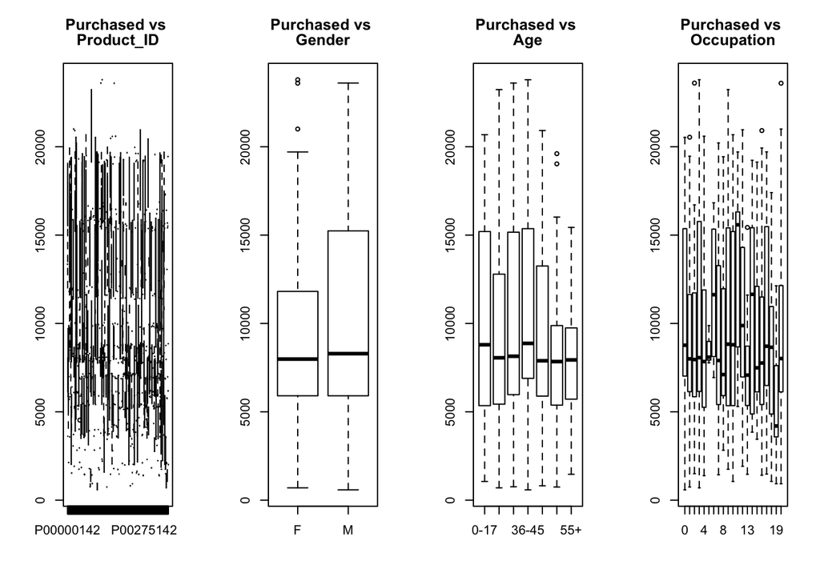

```r
x = dataset.training[,2:11]
y = dataset.training$Purchase

par(mfrow=c(1,4))
  for(i in 1:4) {
  boxplot(y ~ x[,i], main=c("Purchased vs ",names(x)[i]))
  }
```

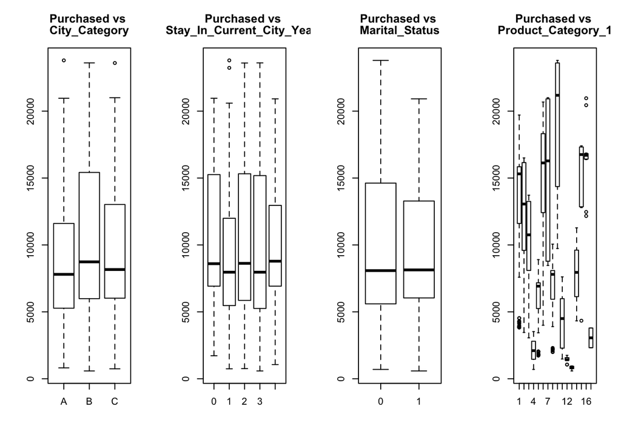

```r
par(mfrow=c(1,4))
  for(i in 5:8) {
  boxplot(y ~ x[,i], main=c("Purchased vs ",names(x)[i]))
  }
```

## 6 - Observations about the data

#### Imputation

The only missing values are in vectors *Product_Category_2* and *Product_Category_3*.

```r
# convert the acceptable NAs to new dummy category
dataset.training[is.na(dataset.training)] <- 'None'

# coerse the datatypes to their intended meaning
dataset.training$User_ID <- as.integer(as.character(dataset.training$User_ID))
dataset.training$Product_ID <- as.integer(dataset.training$Product_ID)
dataset.training$Marital_Status <- as.factor(as.character(dataset.training$Marital_Status))
dataset.training$Product_Category_1 <- as.factor(as.character(dataset.training$Product_Category_1))
dataset.training$Product_Category_2 <- as.factor(as.character(dataset.training$Product_Category_2))
dataset.training$Product_Category_3 <- as.factor(as.character(dataset.training$Product_Category_3))

str(dataset.training)
```

```
## 'data.frame':    995 obs. of  12 variables:
##  $ User_ID                   : int  1000001 1000001 1000001 1000001 1000002 1000003 1000004 1000004 1000004 1000005 ...
##  $ Product_ID                : int  142 493 171 163 559 392 372 661 699 536 ...
##  $ Gender                    : Factor w/ 2 levels "F","M": 1 1 1 1 2 2 2 2 2 2 ...
##  $ Age                       : Factor w/ 7 levels "0-17","18-25",..: 1 1 1 1 7 3 5 5 5 3 ...
##  $ Occupation                : int  10 10 10 10 16 15 7 7 7 20 ...
##  $ City_Category             : Factor w/ 3 levels "A","B","C": 1 1 1 1 3 1 2 2 2 1 ...
##  $ Stay_In_Current_City_Years: Factor w/ 5 levels "0","1","2","3",..: 3 3 3 3 5 4 3 3 3 2 ...
##  $ Marital_Status            : Factor w/ 2 levels "0","1": 1 1 1 1 1 1 2 2 2 2 ...
##  $ Product_Category_1        : Factor w/ 16 levels "1","10","11",..: 11 1 4 4 16 1 1 1 1 16 ...
##  $ Product_Category_2        : Factor w/ 17 levels "10","11","12",..: 17 13 17 5 17 9 15 6 7 17 ...
##  $ Product_Category_3        : Factor w/ 16 levels "10","11","12",..: 16 5 16 16 16 16 8 16 16 16 ...
##  $ Purchase                  : int  8370 15200 1422 1057 7969 15227 19215 15854 15686 7871 ...
```

#### Outliers

```r
# if there are outliers, remove them
outliers <- boxplot(dataset.training$Purchase, plot=F)$out
if (length(outliers) > 0) {
  dataset.training <- dataset.training[-which(dataset.training$Purchase %in% outliers),]
  }
```

## 7 - Modeling without creating any new features

Try *linear regression*, *random forest*, and *xgboost*.

Hyperparameter tuning done in a seperate notebook, but chosen parameters below.

#### Create a one-hot encoded sparse matrix of all the factors

```r
dummies <- dummyVars(~ ., data=dataset.training)
dataset.training.onehot_encoded <- as.data.frame(predict(dummies, newdata = dataset.training))
str(dataset.training.onehot_encoded)
```

```
## 'data.frame':    995 obs. of  72 variables:
##  $ User_ID                      : num  1e+06 1e+06 1e+06 1e+06 1e+06 ...
##  $ Product_ID                   : num  142 493 171 163 559 392 372 661 699 536 ...
##  $ Gender.F                     : num  1 1 1 1 0 0 0 0 0 0 ...
##  $ Gender.M                     : num  0 0 0 0 1 1 1 1 1 1 ...
##  $ Age.0-17                     : num  1 1 1 1 0 0 0 0 0 0 ...
##  $ Age.18-25                    : num  0 0 0 0 0 0 0 0 0 0 ...
##  $ Age.26-35                    : num  0 0 0 0 0 1 0 0 0 1 ...
##  $ Age.36-45                    : num  0 0 0 0 0 0 0 0 0 0 ...
##  $ Age.46-50                    : num  0 0 0 0 0 0 1 1 1 0 ...
##  $ Age.51-55                    : num  0 0 0 0 0 0 0 0 0 0 ...
##  $ Age.55+                      : num  0 0 0 0 1 0 0 0 0 0 ...
##  $ Occupation                   : num  10 10 10 10 16 15 7 7 7 20 ...
##  $ City_Category.A              : num  1 1 1 1 0 1 0 0 0 1 ...
##  $ City_Category.B              : num  0 0 0 0 0 0 1 1 1 0 ...
```

[output cut: 58 more lines]

#### Set up the test harness

```r
# Define the training control
train.control <- trainControl(method = 'cv', number = 5)
```

#### Set up the tuning grid for XGBoost

I experimented in another notebook to get these parameters.

```r
tune.grid.for.xgb <- expand.grid(nrounds=50,
                                lambda=10,
                                alpha=1,
                                eta=0.3
)
```

#### Train the models:

```r
# train linear regression
model.lm <- train(Purchase ~ .,
                 data=dataset.training,
                 method='lm',
                 tuneLength=5,
                 trControl=train.control)

# train xgboost
model.xgb <- train(Purchase ~.,
                   data=dataset.training.onehot_encoded,
                   method="xgbLinear",
                   trControl=train.control,
                   tuneGrid=tune.grid.for.xgb,
                   tuneLength=5
                   )

# train random forest
model.rf <- train(Purchase ~ .,
                 data=dataset.training,
                 method='ranger',
                 tuneLength=5,
                 trControl=train.control)
```

#### Compare LM, XGB, and RF

```r
# Compare model performances using resample()
models.compared <- resamples(list(`Linear Regression`=model.lm,
                                  `XGBoost`=model.xgb,
                                  `Random Forest`=model.rf
                                  ))
# Summary of the models performances
summary(models.compared)
```

```
##
## Call:
## summary.resamples(object = models.compared)
##
## Models: Linear Regression, XGBoost, Random Forest
## Number of resamples: 5
##
## MAE
##                       Min.  1st Qu.   Median     Mean  3rd Qu.     Max.
## Linear Regression 2331.538 2445.312 2525.333 2495.208 2543.589 2630.267
## XGBoost           2386.492 2493.795 2500.094 2486.815 2505.992 2547.703
## Random Forest     2246.689 2411.148 2487.846 2473.148 2516.549 2703.505
##                   NA's
## Linear Regression    0
## XGBoost              0
## Random Forest        0
##
## RMSE
##                       Min.  1st Qu.   Median     Mean  3rd Qu.     Max.
## Linear Regression 3302.860 3307.562 3319.069 3380.128 3399.255 3571.893
## XGBoost           3214.507 3242.782 3270.126 3302.960 3372.193 3415.190
## Random Forest     3040.132 3145.182 3256.081 3268.002 3345.155 3553.461
##                   NA's
## Linear Regression    0
## XGBoost              0
## Random Forest        0
##
## Rsquared
##                        Min.   1st Qu.    Median      Mean   3rd Qu.
## Linear Regression 0.5219374 0.5608737 0.5623637 0.5713094 0.6052323
## XGBoost           0.5597153 0.5776677 0.5855532 0.5875289 0.6034390
## Random Forest     0.5633154 0.5661452 0.6041824 0.5946228 0.6190835
##                        Max. NA's
## Linear Regression 0.6061400    0
## XGBoost           0.6112694    0
## Random Forest     0.6203874    0
```

## 7 - Model observations so far

Linear regression performs the worst. Random Forest (with no tuning or feature engineering at all) performs as well as XGBoost which took a lot of effort in tuning. In production I would go with Random Forest because it can rolled out quickly and automated easily.

Let’s see if we can improve the results further.

### 8 - Feature engineering to improve RMSE score

##### Create new features ‘Product_Count_For_Customer’ and ‘Customer_Count_For_Product’, and ‘Mean_Product_Price’

```r
# Product_Count_For_Customer
Product_Count_For_Customer <- ddply(dataset.training.onehot_encoded, .(User_ID), nrow)
names(Product_Count_For_Customer)[2] <- "Product_Count_For_Customer"
dataset.training.onehot_encoded <- merge(dataset.training.onehot_encoded, Product_Count_For_Customer, by="User_ID")

# Customer_Count_For_Product
Customer_Count_For_Product <- ddply(dataset.training.onehot_encoded, .(Product_ID), nrow)
names(Customer_Count_For_Product)[2] <- "Customer_Count_For_Product"
dataset.training.onehot_encoded <- merge(dataset.training.onehot_encoded, Customer_Count_For_Product, by="Product_ID")

# Mean_Product_Price
Mean_Product_Price <- ddply(dataset.training.onehot_encoded, .(Product_ID), summarize, Mean_Product_Price=mean(Purchase))
dataset.training.onehot_encoded <- merge(dataset.training.onehot_encoded, Mean_Product_Price, by="Product_ID")
```

#### Train the models:

```r
# train linear regression
model.lm <- train(Purchase ~ .,
                 data=dataset.training,
                 method='lm',
                 tuneLength=5,
                 trControl=train.control)

# train xgboost
model.xgb <- train(Purchase ~.,
                   data=dataset.training.onehot_encoded,
                   method="xgbLinear",
                   trControl=train.control,
                   tuneGrid=tune.grid.for.xgb,
                   tuneLength=5
                   )

# train random forest
model.rf <- train(Purchase ~ .,
                 data=dataset.training,
                 method='ranger',
                 tuneLength=5,
                 trControl=train.control)
```

#### Compare LM, XGB, and RF

```r
# Compare model performances using resample()
models.compared <- resamples(list(`Linear Regression`=model.lm,
                                  `XGBoost`=model.xgb,
                                  `Random Forest`=model.rf
                                  ))
# Summary of the models performances
summary(models.compared)
```

```
##
## Call:
## summary.resamples(object = models.compared)
##
## Models: Linear Regression, XGBoost, Random Forest
## Number of resamples: 5
##
## MAE
##                       Min.  1st Qu.   Median     Mean  3rd Qu.     Max.
## Linear Regression 2410.257 2412.576 2431.293 2467.362 2484.240 2598.446
## XGBoost           1063.207 1097.550 1213.059 1196.072 1289.881 1316.665
## Random Forest     2233.257 2486.264 2493.231 2470.586 2565.595 2574.583
##                   NA's
## Linear Regression    0
## XGBoost              0
## Random Forest        0
##
## RMSE
##                       Min.  1st Qu.   Median     Mean  3rd Qu.     Max.
## Linear Regression 3206.064 3222.062 3262.145 3301.275 3405.760 3410.345
## XGBoost           1903.493 1973.320 2011.558 2032.398 2128.996 2144.625
## Random Forest     2959.764 3281.456 3285.356 3277.577 3421.328 3439.982
##                   NA's
## Linear Regression    0
## XGBoost              0
## Random Forest        0
##
## Rsquared
##                        Min.   1st Qu.    Median      Mean   3rd Qu.
## Linear Regression 0.5458989 0.5833248 0.5861625 0.5870898 0.5919103
## XGBoost           0.8228316 0.8293838 0.8495789 0.8442317 0.8527019
## Random Forest     0.5358705 0.5472527 0.6036907 0.5911323 0.6051834
##                        Max. NA's
## Linear Regression 0.6281526    0
## XGBoost           0.8666622    0
## Random Forest     0.6636645    0
```

# Conclusion

Model performance was the same for all algorthims, until feature engineering was introduced. Adding features that emphasized small variances in the data allowed XGBoost to vastly outperform linear regression and random forest.